# Week 2 Project 1

### Loading the data

First, the data is loaded in to R and the date column transformed using the following code:

```r
activity <- read.csv("activity.csv")
activity[,2]<-as.Date(activity$date)
```

## Data Analysis

### What is the mean total number of steps taken per day?

This block of code produces a histogram illustrating total number of steps per day.

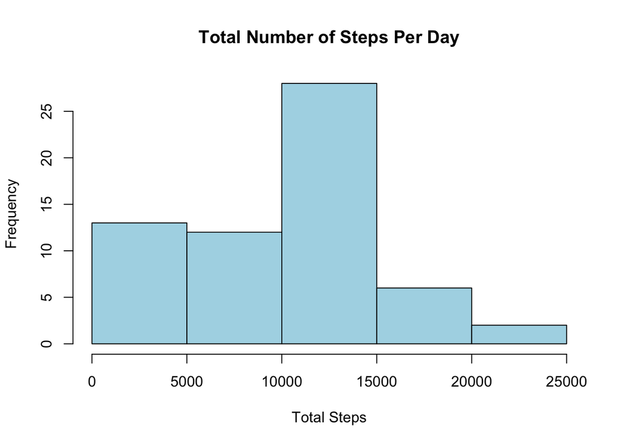

```r
steps<-with(activity, tapply(steps, date, sum, na.rm=TRUE))
hist(steps, col="lightblue", xlab="Total Steps", ylab="Frequency", main = "Total Number of Steps Per Day" )
```

```r
mean_steps<-mean(steps)
median_steps<-median(steps)
print(c(mean_steps, median_steps))
```

```
## [1]  9354.23 10395.00
```

## What is the average daily activity pattern?

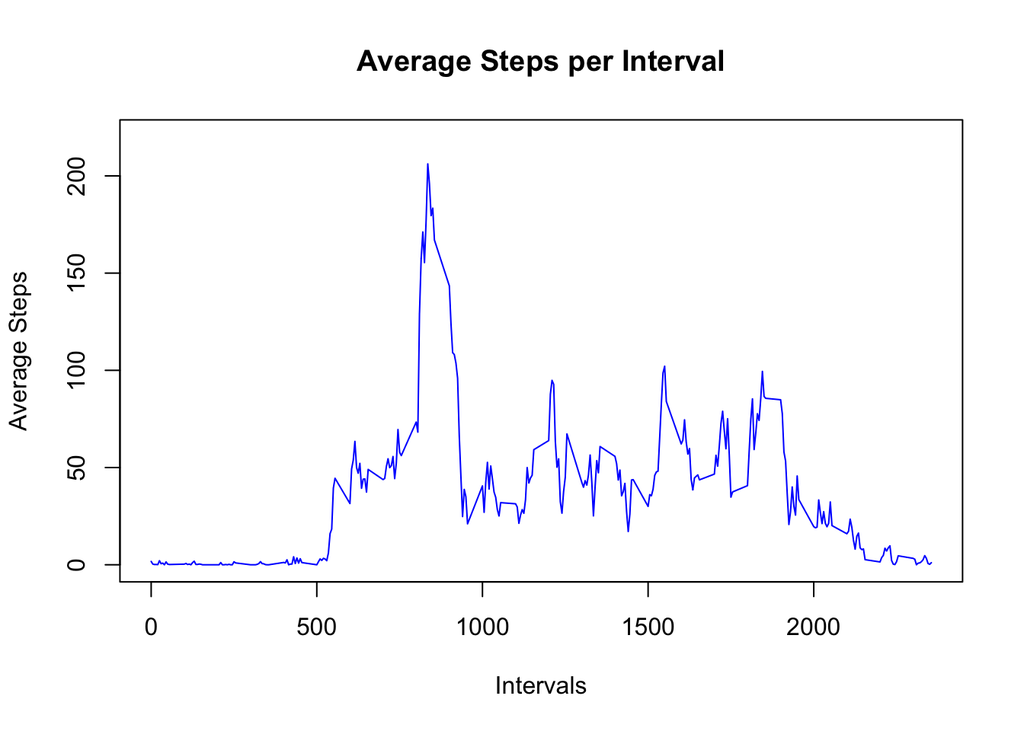

```r
stepsPerInterval<-aggregate(steps~interval, data=activity, mean, na.rm=TRUE)
plot(steps~interval, data=stepsPerInterval,type="l", ylim=c(0, 220), col="blue", xlab="Intervals", ylab="Average Steps", main="Average Steps per Interval")
```

### Which 5-minute interval, on average across all the days in the dataset, contains the maximum number of steps?

```r
max_intervals<-stepsPerInterval[which.max(stepsPerInterval$steps),]$interval
print(max_intervals)
```

```
## [1] 835
```

## Imputing missing values

### How many missing values are there in this dataset?

```r
activity_missing<-sum(is.na(activity$steps))
print(activity_missing)
```

```
## [1] 2304
```

There are 2304 missing values.

### Strategy for filling in missing values

The following block of code fills in all missing values in the dataset with the mean and saves this dataset as Activity_noNA

```r
MeanPerInterval<-function(interval){
        stepsPerInterval[stepsPerInterval$interval==interval,]$steps
}

activity_noNA<-activity
for(i in 1:nrow(activity_noNA)){
        if(is.na(activity_noNA[i,]$steps)){
                activity_noNA[i,]$steps<-MeanPerInterval(activity_noNA[i,]$interval)
        }
}
```

### Comparing the original dataset with the new dataset with imputed missing data

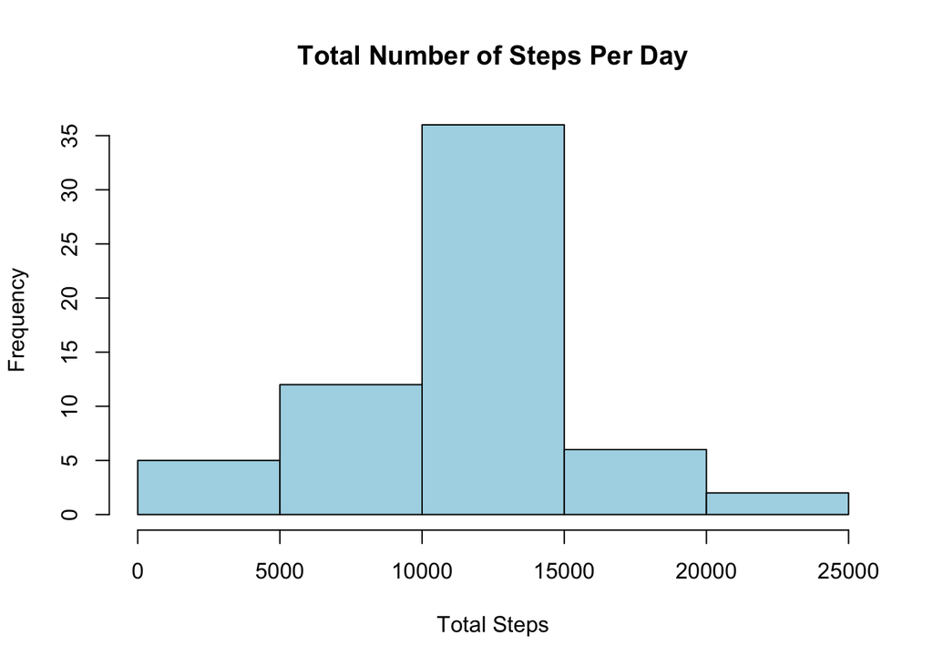

```r
total_steps_noNA<- aggregate(steps~date, data=activity_noNA, sum)
hist(total_steps_noNA$steps, col="lightblue", xlab="Total Steps", ylab="Frequency", main = "Total Number of Steps Per Day" )
```

```r
mean_steps_noNA<-mean(total_steps_noNA$steps)
median_steps_noNA<-median(total_steps_noNA$steps)
```

## Are there differences in activity patterns between weekdays and weekends?

To answer this, a factor variable (“wk”) has been created with two levels - “weekday” and “weekend”.

```r
is_weekday<-function(act_pattern){
        wd<-weekdays(act_pattern)
        ifelse(wd=="Saturday"| wd =="Sunday", "weekend", "weekday")
}

wk2<-sapply(activity_noNA$date, is_weekday)
activity_noNA$wk<-as.factor(wk2)
```

A panel plot will now be created of a timeseries plot of the 5-minute interval and the average number of steps taken, averaged across all weekday days or weekend days. The lattice package will be used to create this.

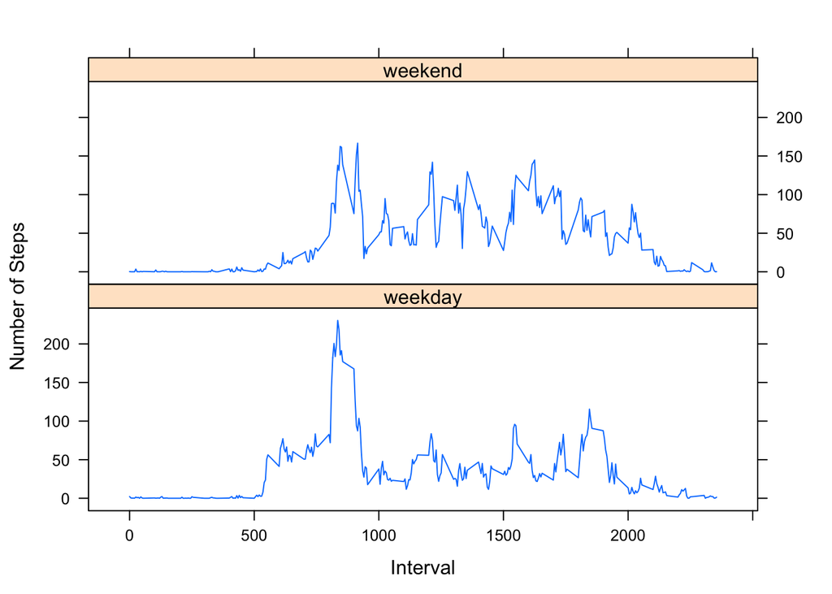

```r
wk_df<-aggregate(steps~wk +interval, data=activity_noNA, FUN=mean)

library(lattice)
xyplot(steps~interval|factor(wk), layout=c(1, 2), xlab="Interval", ylab="Number of Steps", type="l", data=wk_df)
```